# Signal Processing

### Moving average or runnnig mean

A moving average filter is a column–wise operation which average contiguous wavelengths within a given window size.

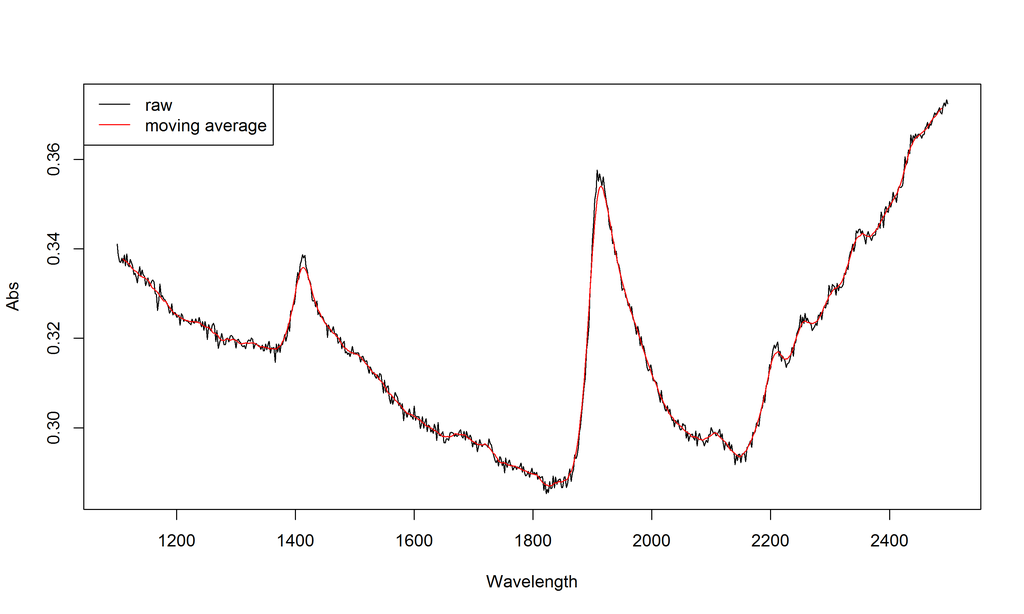

```r
noisy <- NIRsoil$spc + rnorm(length(NIRsoil$spc), 0, 0.001)  # adding some noise
# Plot the first spectrum
plot(as.numeric(colnames(NIRsoil$spc)), noisy[1, ], type = "l", xlab = "Wavelength",
    ylab = "Abs")
X <- movav(noisy, w = 11)  # window size of 11 bands
# Note that the 5 first and last bands are lost in the process
lines(as.numeric(colnames(X)), X[1, ], col = "red")
legend("topleft", legend = c("raw", "moving average"), lty = c(1, 1), col = 1:2)
```

### Binning

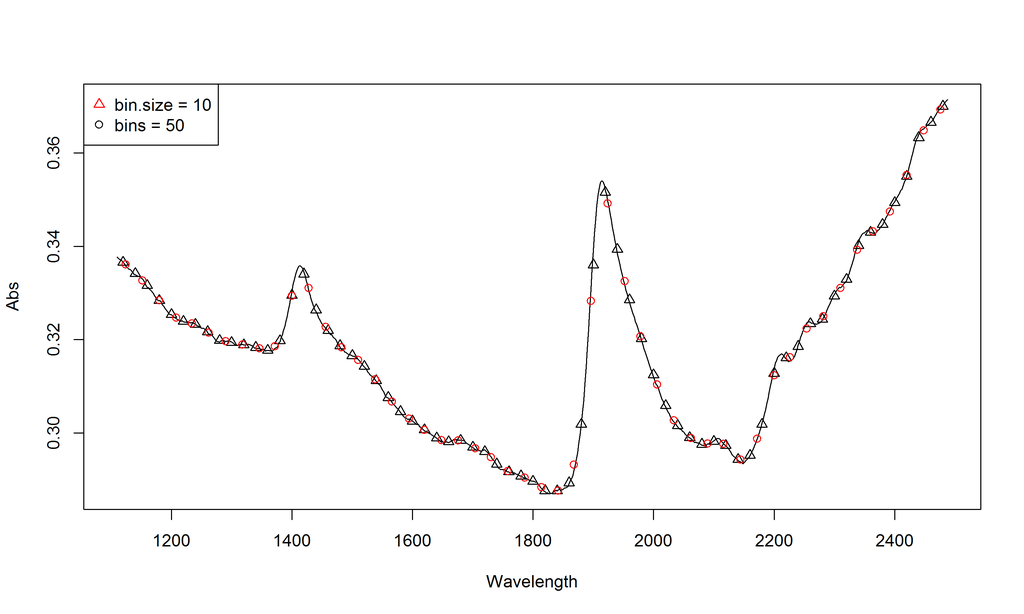

```r
# After averaging, the spectrum can be further resampled (binning)
X.bin <- binning(X, bin.size = 10)  # We keep here one 1 out every 10 data points
X.bin2 <- binning(X, bins = 50)  # We reduce the spectral matrix to 50 (equally-spaced) data points
# Plot the first spectrum
plot(as.numeric(colnames(X)), X[1, ], type = "l", xlab = "Wavelength", ylab = "Abs")
# new data points
points(as.numeric(colnames(X.bin)), X.bin[1, ], pch = 2)
points(as.numeric(colnames(X.bin2)), X.bin2[1, ], pch = 1, col = 2)
legend("topleft", legend = c("bin.size = 10", "bins = 50"), pch = 2:1, col = 2:1)
```

### Savitzky-Golay filtering

Savitzky-Golay filtering [@savitzky1964] is a very common preprocessing technique. It fits a local polynomial regression on the signal and requires **equidistant** bandwidth. Mathematically, it operates simply as a weighted sum of neighbouring values:

\[ x_j\ast = \frac{1}{N}\sum_{h=-k}^{k}{c_hx_{j+h}} \]

where \( x_j\ast \) is the new value, \( N \) is a normalizing coefficient, \( k \) is the number of neighbour values at each side of \( j \) and \( c_h \) are pre–computed coefficients, that depends on the chosen polynomial order and degree (smoothing, first and second derivative)

```r
# p = polynomial order w = window size (must be odd) m = m-th derivative
# (0 = smoothing) The function accepts vectors or matrices. For a matrix
# input, observations should be arranged row-wise
sg.vec <- savitzkyGolay(NIRsoil$spc[1, ], p = 3, w = 11, m = 0)
sg <- savitzkyGolay(NIRsoil$spc, p = 3, w = 11, m = 0)
# note that bands at the edges of the spectral matrix are lost !
dim(NIRsoil$spc)
```

```
## [1] 825 700
```

```r
dim(sg)
```

```
## [1] 825 690
```

## Derivatives

Taking (numerical) derivatives of the spectra can remove both additive and multiplicative effects in the spectra and have other consequences as well (Table 3).

Advantage Drawback

Reduce of baseline offset Risk of overfitting the calibration model Can resolve absorption overlapping Increase noise, smoothing required Compensates for instrumental drift Increase uncertainty in model coefficients  
Enhances small spectral absorptions Complicate spectral interpretation Often increase predictive accuracy Remove the baseline ! for complex datasets

Table 3: Pro's and con's of using derivative spectra.

First and second derivatives of a spectrum can be computed with the finite difference method (difference between to subsequent data points), provided that the band width is constant:

\[ x_i' = x_i - x_{i-1} \]

\[ x_i'' = x_{i-1} - 2 \cdot x_i + x_{i+1} \]

In R, this can be simply achieved with the `diff` function in `base`:

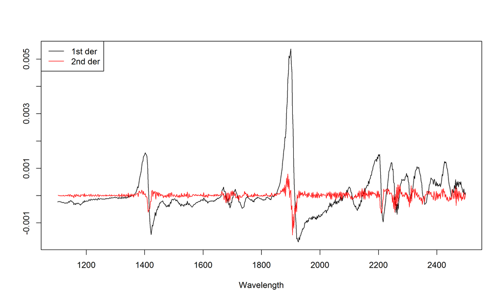

```r
# X = wavelength Y = spectral matrix n = order
d1 <- t(diff(t(NIRsoil$spc), differences = 1))  # first derivative
d2 <- t(diff(t(NIRsoil$spc), differences = 2))  # second derivative
plot(as.numeric(colnames(d1)), d1[1, ], type = "l", xlab = "Wavelength", ylab = "")
lines(as.numeric(colnames(d2)), d2[1, ], col = "red")
legend("topleft", legend = c("1st der", "2nd der"), lty = c(1, 1), col = 1:2)
```

One can see that derivatives tend to increase noise. One can use gap derivatives or the Savitzky-Golay algorithm to solve this. The gap derivative is computed simply as:

\[ x_i' = x_{i+k} - x_{i-k} \]

\[ x_i'' = x_{i-k} - 2 \cdot x_i + x_{i+k} \]

where \( k \) is the gap size. Again, this can be easily achieved in R using the `lag` argument of the `diff` function

```r
gd1 <- t(diff(t(NIRsoil$spc), differences = 1, lag = 10))  # first derivative with a gap of 10 bands
```

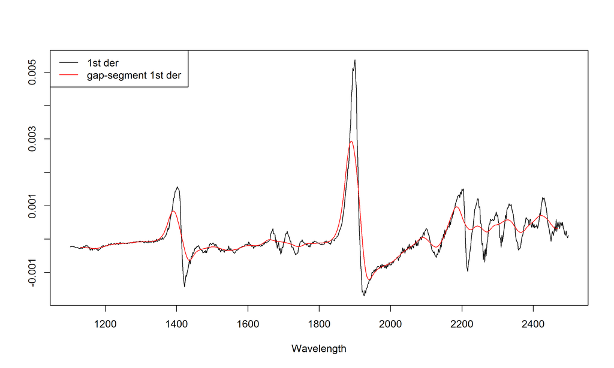

```r
# m = order of the derivative w = window size ( = {2 * gap size} + 1) s =
# segment size
gsd1 <- gapDer(X = NIRsoil$spc, m = 1, w = 11, s = 10)  # first derivative with a gap of 10 bands
plot(as.numeric(colnames(d1)), d1[1, ], type = "l", xlab = "Wavelength", ylab = "")
lines(as.numeric(colnames(gsd1)), gsd1[1, ], col = "red")
legend("topleft", legend = c("1st der", "gap-segment 1st der"), lty = c(1, 1),
    col = 1:2)
```

## Scatter corrections

Undesired spectral variations due to light *scatter* effects and variations in effective *path length* can be removed using scatter corrections.

### Standard Normal Variate (SNV)

*SNV* is another simple way for normalizing spectra that intends to correct for light *scatter*. It operates row–wise:

\[ SNV_i = \frac{x_i - \bar{x_i}}{s_i} \]

```r
snv <- standardNormalVariate(X = NIRsoil$spc)
```

According to Fearn [@fearn2008], it is better to perform SNV transformation after filtering (by e.g. Savitzky–Golay) than the reverse

### SNV-Detrend

The *SNV-Detrend* [@barnes1989] further accounts for wavelength-dependent scattering effects (variation in curvilinearity between the spectra). After a *SNV* transformation, a 2\( ^{nd} \)–order polynomial is fit to the spectrum and subtracted from it

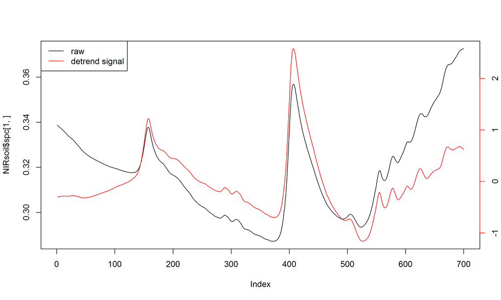

```r
# X = input spectral matrix wav = band centers
dt <- detrend(X = NIRsoil$spc, wav = as.numeric(colnames(NIRsoil$spc)))
plot(NIRsoil$spc[1, ], type = "l")
par(new = T)
plot(dt[1, ], xaxt = "n", yaxt = "n", xlab = "", ylab = "", col = "red", type = "l")
axis(4, col = "red")
legend("topleft", legend = c("raw", "detrend signal"), lty = c(1, 1), col = 1:2)
```

```r
par(new = F)
```

## Centering and scaling

Centering and scaling tranforms a given matrix to a matrix with columns with zero mean (*centering*), unit variance (*scaling*) or both (*auto-scaling*):

\[ Xc_{ij} = X_{ij} - \bar{X}_{j} \]

\[ Xs_{ij} = \frac{X_{ij} - \bar{X}_{j}}{s_{j}} \]

where \( Xc \) and \( Xs \) are the mean centered and auto-scaled matrices, \( X \) is the input matrix, \( \bar{X}_{j} \) and \( s_{j} \) are the mean and standard deviation of variable \( j \).

In R, these operations are simply obtained with the `scale` function. Other types of scaling can be considered. Spectroscopic models can often be improved by using ancillary data (e.g. temperature, …) [@fearn2010]. Due to the nature of spectral data (multivariate), other data would have great chance to be dominated by the spectral matrix and have no chance to contribute significantly to the model due to purely numerical reasons [@eriksson2006]. One can use *block scaling* to overcome this limitation. It basically uses different weights for different block of variables. With *soft block scaling*, each block is scaled (ie each column divided by a factor) such that the sum of their variance is equal to the square root of the number of variables in the block. With *hard block scaling*, each block is scaled such that the sum of their variance is equal to 1.

```r
# X = spectral matrix type = 'soft' or 'hard' The ouptut is a list with
# the scaled matrix (Xscaled) and the divisor (f)
bs <- blockScale(X = NIRsoil$spc, type = "hard")$Xscaled
sum(apply(bs, 2, var))  # this works!
```

```
## [1] 1
```

The problem with *block scaling* is that it down–scale all the block variables to the same variance. Since sometimes this is not advised, one can alternatively use *sum of squares block weighting* . The spectral matrix is multiplied by a factor to achieve a pre–determined sum of square:

```r
# X = spectral matrix targetnorm = desired norm for X
bn <- blockNorm(X = NIRsoil$spc, targetnorm = 1)$Xscaled
sum(bn^2)  # this works!
```

```
## [1] 1
```

## Other transformations

### Continuum removal

The continuum removal technique was introduced by [@clark1984] as an effective method to highlight absorption features of minerals. It can be viewed as an albedo normalization technique. This technique is based on the computation of the continuum (or envelope) of a given spectrum. The continuum-removed spectrum of a given spectrum is computed as follows:

1. The local reflectance spectrum maxima points (in the case of absorbance, local minima points) are identified.
2. Then, these points are connected by linear interpolation to form the continuum.
3. The continuum-removed spectrum is given by \( \phi_{i} = \frac{x_{i}}{c_{i}}; i=\left \{ 1,..., p\right\} \), where \( x_{i} \) and \( c_{i} \) are the original and the continuum reflectance (or absorbance) values respectively at the \( i \)<sup>th</sup> wavelength of a set of \( p \) wavelengths, and \( \phi_{i} \) is the respective final reflectance (or absorbance) value after continuum removal.

The `continuumRemoval` function allows to compute the continuum-removed values of either reflectance or absorbance spectra.

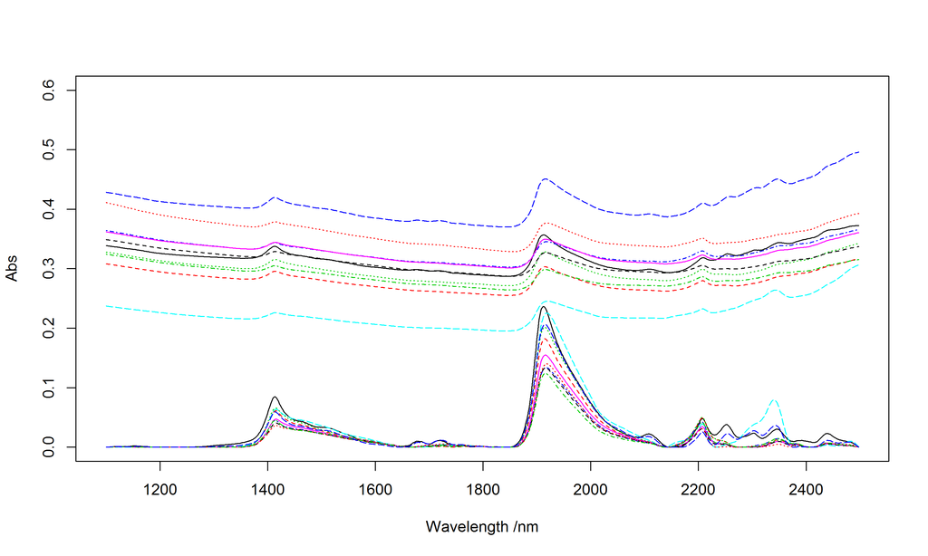

```r
# type of data: 'R' for reflectance (default), 'A' for absorbance
cr <- continuumRemoval(X = NIRsoil$spc, type = "A")
# plot of the 10 first abs spectra
matplot(as.numeric(colnames(NIRsoil$spc)), t(NIRsoil$spc[1:10, ]), type = "l",
    ylim = c(0, 0.6), xlab = "Wavelength /nm", ylab = "Abs")
matlines(as.numeric(colnames(NIRsoil$spc)), t(cr[1:10, ]))
```

### Resampling

To match the response of one instrument with another, a signal can be resampled to new band positions by simple interpolation (`resample`) or using full width half maximum (FWHM) values (`resample2`).

# Calibration sampling algorithms

Calibration models are usually developed on a *representative* portion of the data (training set) and validated on the remaining set of samples (test/validation set). There are several solutions for selecting samples, e.g.:

- random selection (see e.g. `sample` function in `base`)
- stratified random sampling on percentiles of the response \( y \) (see e.g. `createDataPartion` in the [`caret`](http://cran.r-project.org/web/packages/caret/index.html) package)
- use the spectral data.

For selecting representative samples, the `prospect` package provides functions that use the third solution. The following functions are available: `kenStone` [@kennard1969], `duplex` [@snee1977], `puchwein` [@puchwein1988], `shenkWest` [@shenk1991], `naes` [@naes2002], `honigs` [@honigs1985].

### Kennard-Stone sampling (`kenStone`)

To sample a subset of \( n \) samples \( \mathrm{X_{tr}} = \left \{ \mathrm{x_{tr}}_{j} \right \}_{j=1}^{n} \), from a given set of \( N \) samples \( \mathrm{X} = \left \{ \mathrm{x}_i \right \}_{i=1}^{N} \) (note that \( N>n \)) the Kennard-Stone sampling algorithm consists in [@kennard1969]:

1. Find in \( \mathrm{X} \) the samples \( \mathrm{x_{tr1}} \) and \( \mathrm{x_{tr2}} \) that are the farthest apart from each other, allocate them in \( \mathrm{X_{tr}} \) and remove them from \( \mathrm{X} \).
2. Find in \( \mathrm{X} \) the sample \( \mathrm{x_{tr3}} \) which is the most dissimilar to the ones already allocated in \( \mathrm{X_{tr}} \). Allocate \( \mathrm{x_{tr3}} \) in \( \mathrm{X_{tr}} \) and then remove it from \( \mathrm{X} \). Note that the dissimilarity between \( \mathrm{X_{tr}} \) and each \( \mathrm{x}_i \) is given by the minimum distance of any sample allocated in \( \mathrm{X_{tr}} \) to each \( \mathrm{x}_i \). In other words, the selected sample is one of the nearest neighbours of the points already selected which is characterized by the maximum distance to the other points already selected.
3. Repeat the step 2 n-3 times in order to select the remaining samples (\( \mathrm{x_{tr4}},..., \mathrm{x_{tr}}_n \)).

The Kennard–Stone algorithm allows to create a calibration set that has a flat distribution over the spectral space. The metric used to compute the distance between points can be either the Euclidean distance or the Mahalanobis distance. Let's see some examples…

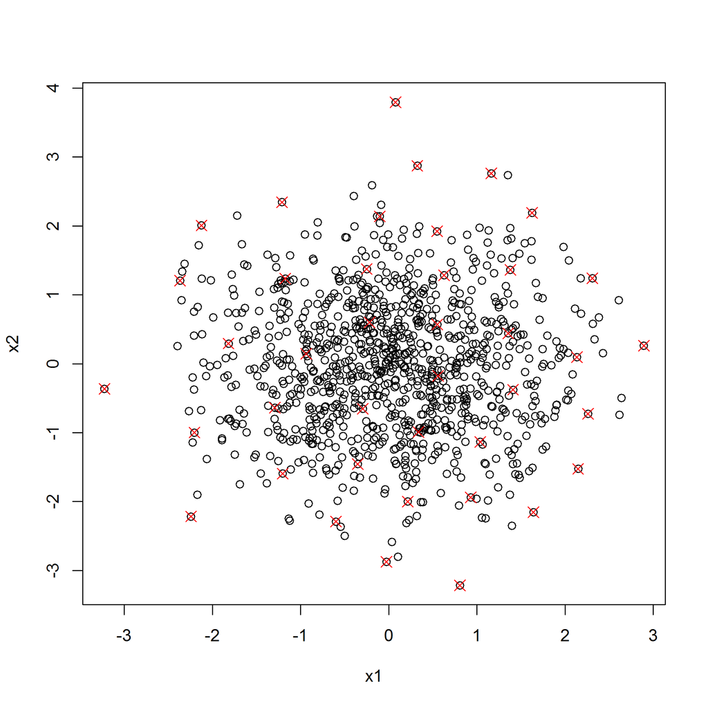

```r
# Create a dataset for illustrating how the calibration sampling
# algorithms work
X <- data.frame(x1 = rnorm(1000), x2 = rnorm(1000))
plot(X)
ken <- kenStone(X, k = 40)  # Produce a list with row index of the points selected for calibration
points(X[ken$model, ], col = 2, pch = 4, cex = 1.4)  # plot selected points
```

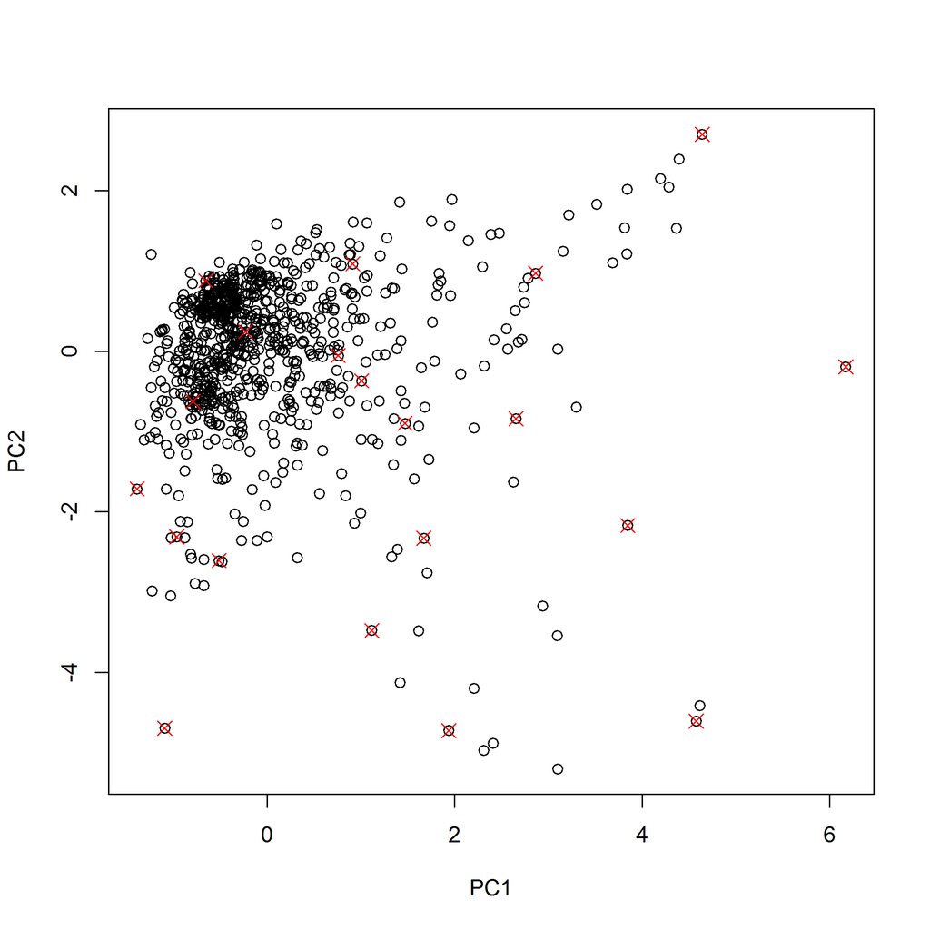

```r
# Test with the NIRsoil dataset one can use the mahalanobis distance The
# mahalanobis distance is computed by taking the Euclidean distance in the
# normalized principal component score space (see Maesschalck et al. 2000,
# Chemo. Int. Lab. Syst. 50, 1-18) If the 'pc' argument is set, the
# Mahalanobis distance will be used The 'pc' argument is the number of
# pc's retained in the computation of the distance if 'pc' < 1, then it
# corresponds to a treshold in terms of explained variance
ken_mahal <- kenStone(X = NIRsoil$spc, k = 20, pc = 0.999)
# The pc components in the output list stores the pc scores
plot(ken_mahal$pc[, 1], ken_mahal$pc[, 2], xlab = "PC1", ylab = "PC2")
# This is the selected points in the pc space
points(ken_mahal$pc[ken_mahal$model, 1], ken_mahal$pc[ken_mahal$model, 2], pch = 4,
    col = 2, cex = 1.4)
```

### DUPLEX (`duplex`)

The Kennard–Stone algorithm selects *calibration* samples. Often, we need also to select a *validation* subset. The DUPLEX algorithm [@snee1977] is a modification of the Kennard-Stone which allows to select a *validation* set that have similar properties to the *calibration_set. DUPLEX, similarly to Kennard–Stone, begins by selecting pairs of points that are the farthest apart from each other, and then assigns points alternatively to the _calibration* and *validation* sets.

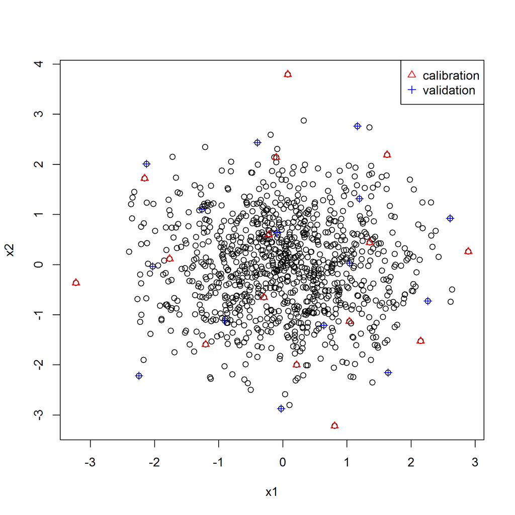

```r
dup <- duplex(X = X, k = 15)  # k is the number of selected samples
plot(X)
points(X[dup$model, 1], X[dup$model, 2], col = "red", pch = 2)  # calibration samples
points(X[dup$test, 1], X[dup$test, 2], col = "blue", pch = 3)  # validation samples
legend("topright", legend = c("calibration", "validation"), pch = 2:3, col = c("red",
    "blue"))
```

### \( k \)-means sampling (`naes`)

The \( k \)-means sampling simply uses \( k \)-means clustering algorithm. To sample a subset of \( n \) samples \( \mathrm{X_{tr}} = \left \{ \mathrm{x_{tr}}_{j} \right \}_{j=1}^{n} \), from a given set of \( N \) samples \( \mathrm{X} = \left \{ \mathrm{x}_i \right \}_{i=1}^{N} \) (note that \( N>n \)) the algorithm works as follows:

1. Perform a \( k \)-means clustering of \( \mathrm{X} \) using \( n \) clusters.
2. Extract the \( n \) centroids (\( c \), or prototypes). This can be also the sample that is the farthest away from the centre of the data, or a random selection. See the `method` argument in `naes`
3. Calculate the distance of each sample to each \( c \).
4. For each \( c \) allocate in \( \mathrm{X_{tr}} \) its closest sample found in \( \mathrm{X} \).

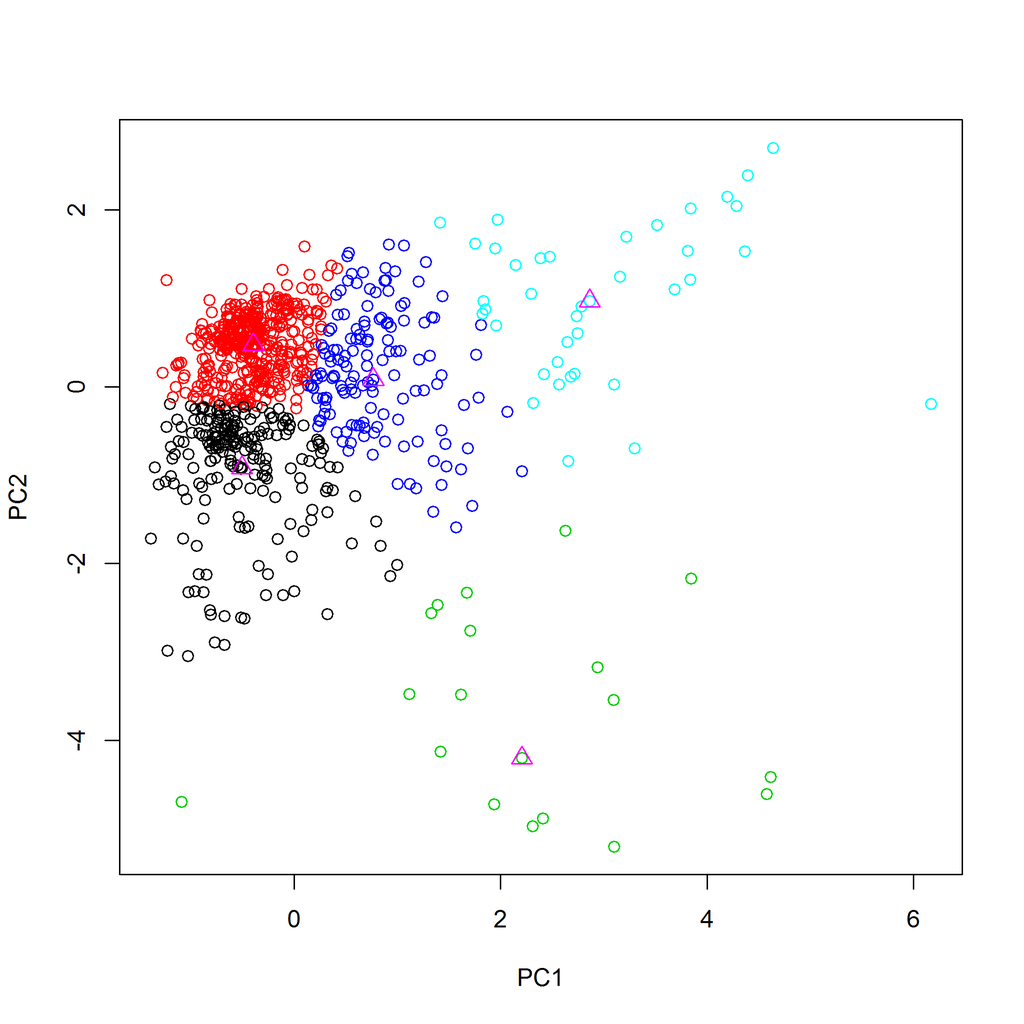

```r
# X = the input matrix k = number of calibration samples to be selected pc
# = if pc is specified, k-mean is performed in the pc space (here we use
# only the two 1st pc) iter.max = maximum number of iterations allowed for
# the k-means clustering.
kms <- naes(X = NIRsoil$spc, k = 5, pc = 2, iter.max = 100)
# Plot the pcs scores and clusters
plot(kms$pc, col = kms$cluster)
# Add the selected points
points(kms$pc[kms$model, ], col = 6, cex = 1.4, pch = 2)
```

### SELECT algorithm (`shenkWest`)

The SELECT algorithm [@shenk1991] is an iterative procedure which selects the sample having the maximum number of neighbour samples within a given distance (`d.min` argument) and remove the neighbour samples of the selected sample from the list of points. The number of selected samples depends on the chosen treshold (default = 0.6). The distance metric is the Mahalanobis distance divided by the number of dimensions (number of pc components) used to compute the distance. Here is an example of how the `shenkWest` function might work:

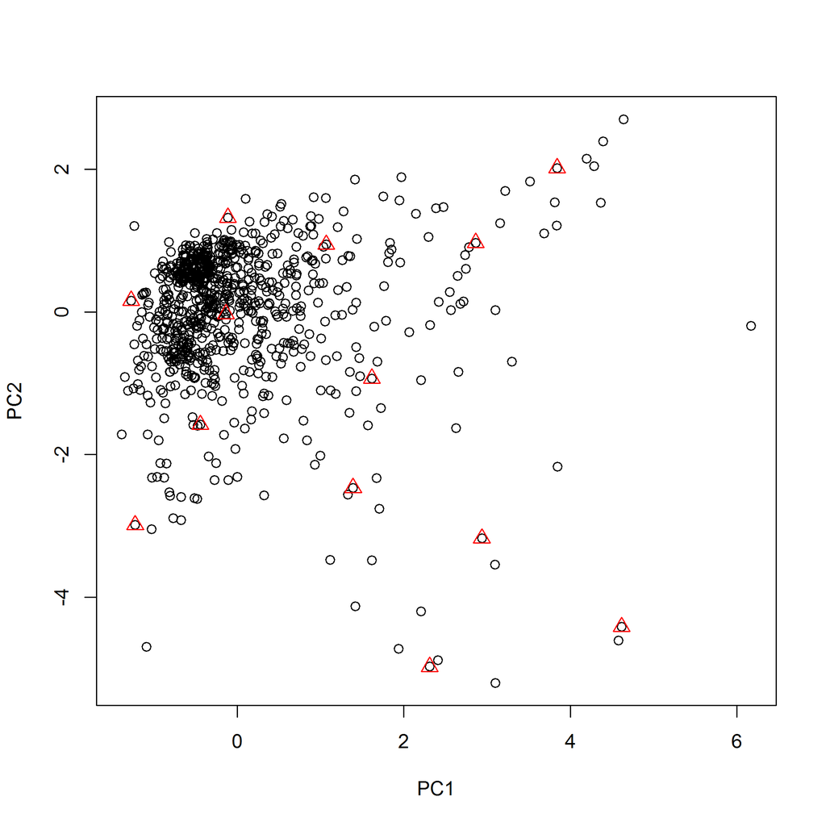

```r
shenk <- shenkWest(X = NIRsoil$spc, d.min = 0.6, pc = 2)
plot(shenk$pc)
points(shenk$pc[shenk$model, ], col = 2, cex = 1.4, pch = 2)
```

### Puchwein algorithm (`puchwein`)

The Puchwein algorithm is yet another algorithm for calibration sampling [@puchwein1988] that create a calibration set with a flat distribution. A nice feature of the algorithm is that it allows an objective selection of the number of required calibration samples with the help of plots. First the data is usually reduced through PCA and the most significant PCs are retained. Then the mahalanobis distance (\( H \)) to the center of the matrix is computed and samples are sorted decreasingly. The distances betwwen samples in the PC space are then computed.

- Here is a `pseudo-code` of the algorithm:

```
1. Definition of a limiting distance
2. Find the sample with $\max(H)$
3. Remove all the samples which are within the limiting distance away from the sample selected in step 2.
4. Go back in step 2 and find the sample with $\max(H)$ within the remaining samples
5. When there is no sample anymore, go back to step 1 and increase the limiting distance.
```

```r
pu <- puchwein(X = NIRsoil$spc, k = 0.2, pc = 2)
plot(pu$pc)
points(pu$pc[pu$model, ], col = 2, pch = 2)  # selected samples
```

[output not shown]

The number of sample selected depends on the limiting distance. To help choosing the appropriate number of samples, two plots are used [@shetty2012]:

```r
# Optimal loop
par(mfrow = c(2, 1))
plot(pu$leverage$removed, pu$leverage$diff, type = "l", xlab = "# samples removed",
    ylab = "Difference between th. and obs sum of leverages")
plot(pu$leverage$loop, nrow(NIRsoil) - pu$leverage$removed, xlab = "# loops",
    ylab = "# samples kept", type = "l")
par(mfrow = c(1, 1))
# This basically shows that the first loop is optimal
```

[output not shown]

### Honigs (`honigs`)

The Honigs algorithm selects samples based on the size of their absorption features [@honigs1985]. It can works both on absorbance and continuum-removed spectra. The sample having the highest absorption feature is selected first. Then this absorption is substracted from other spectra and the algorithm iteratively select samples with the highest absorption (in absolute value) until the desired number of samples is reached.

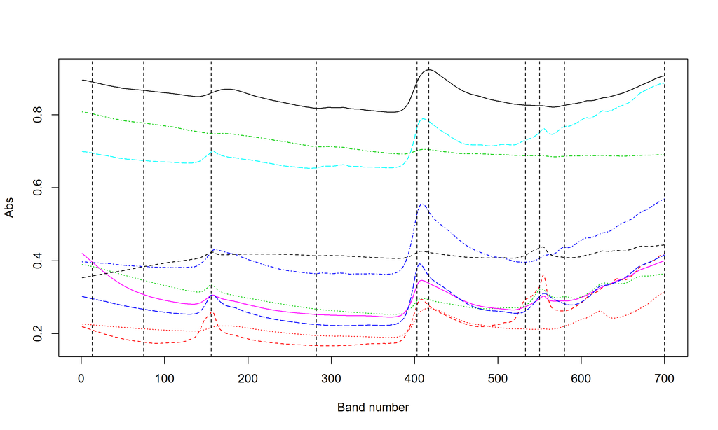

```r
ho <- honigs(X = NIRsoil$spc, k = 10, type = "A")
# plot calibration spectra
matplot(t(NIRsoil$spc[ho$model, ]), type = "l", xlab = "Band number", ylab = "Abs")
# add bands used during the selection process
abline(v = ho$bands, lty = 2)
```